# slide_project_part2 slides

[figure not shown]

### A camera is an optical instrument used to capture an image. At their most basic, cameras are sealed boxes (the camera body) with a small hole (the aperture) that allow light in to capture an image on a light-sensitive surface (usually photographic film or a digital sensor). Cameras have various mechanisms to control how the light falls onto the light-sensitive surface. Lenses focus the light entering the camera, the size of the aperture can be widened or narrowed to let more or less light into the camera, and a shutter mechanism determines the amount of time the photo-sensitive surface is exposed to the light.

### In this project the dataset will be about cameras, their specifications, types, and date of release. The data were collected from 1994 to 2007.

### Questions we will ask for analysis:

### A) Companies:

**1- How many companies are in the dataset?**

**There are 21 different companies**

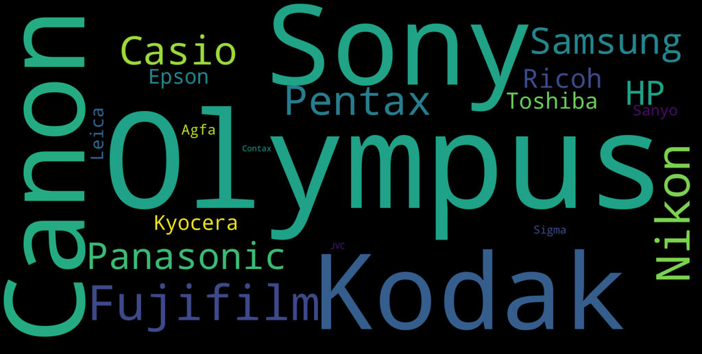

```python
# display the companies

# write the code:

from wordcloud import WordCloud

wordcloud = WordCloud(
    width = 2000,
    height = 1000,repeat=False,
    background_color = 'black')
wordcloud.generate_from_frequencies(df1)
fig = plt.figure(
    figsize = (20, 15),
    facecolor = 'k',
    edgecolor = 'k')
plt.imshow(wordcloud, interpolation = 'bilinear')
plt.axis('off')
plt.tight_layout(pad=0)

# show the plot
plt.show()
```

**2- What are the The percentage of most frequent companies?**

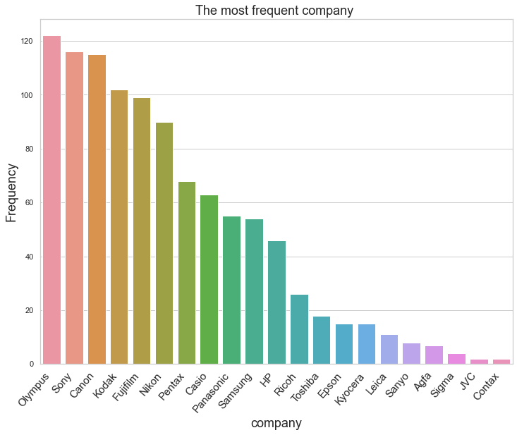

```python
# write the code:

plt.figure(figsize = (12,9))
#bar plot for The most frequent company
ax=sns.countplot(x = 'company', data = df, order = df['company'].value_counts().index);
#Rotate xticklabels
ax.set_xticklabels(ax.get_xticklabels(),rotation = 49, ha= 'right', fontsize = 15);
#Give label to x-axis,y-axis & a title
plt.xlabel('company', fontsize = 18);
plt.ylabel('Frequency',fontsize = 18);
plt.title('The most frequent company ',fontsize = 18);
```

### As we can see, the most frequent company in the data set is Olympus with 122 models, and the least frequent company is JVC and Contax with 2 models.

## B) Prices:

#### 1- What is the relationship between the date of release and prices?

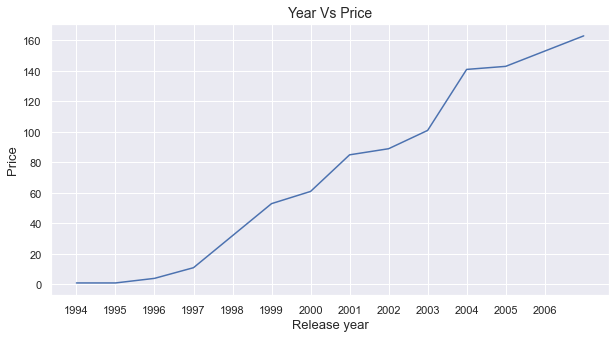

```python
# write the code:
data=df.groupby('Release_date').count()['Price']

df.groupby('Release_date').count()['Price'].plot(xticks = np.arange(1994,2007,1))

#set the figure size and labels
sns.set(rc={'figure.figsize':(20,15)})
plt.title("Year Vs Price",fontsize = 14)
plt.xlabel('Release year',fontsize = 13)
plt.ylabel('Price',fontsize = 13)
#set the style sheet
sns.set_style("whitegrid")
```

**2- What are the 10 most expensive models?**

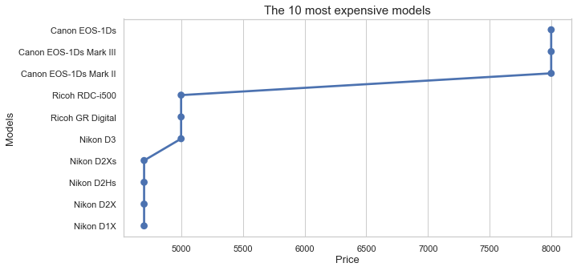

```python
# write the code:

info = pd.DataFrame(df['Price'].sort_values(ascending = False))
info['Model'] = df['Model']
data = list(map(str,(info['Model'])))
x = list(data[:10])
y = list(info['Price'][:10])

# plot the 10 most expensive models
ax = sns.pointplot(x=y,y=x)

#setup the figure size
sns.set(rc={'figure.figsize':(10,5)})
#setup the title and labels of the plot.
ax.set_title("The 10 most expensive models",fontsize = 15)
ax.set_xlabel("Price",fontsize = 13)
ax.set_ylabel("Models",fontsize = 13)
sns.set_style("darkgrid")
```

### C) specifications:

**1- What is the relationship of professional specifications to the weight of the camera?**

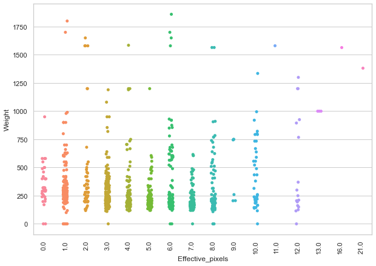

```python
# The relationship of Effective_pixels to the weight
plt.figure(figsize=(10,7))
sns.stripplot(x='Effective_pixels', y='Weight', data=df );
plt.xticks(rotation=90);
```

**2- What are the models that meet the professional specifications?**

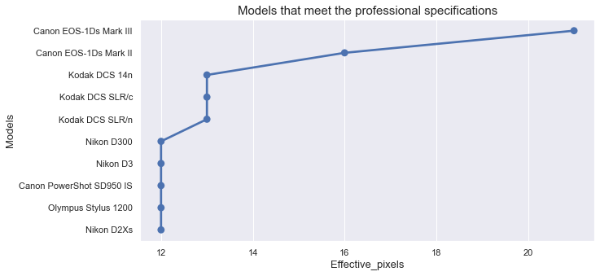

```python
# write the code:

info = pd.DataFrame(df['Effective_pixels'].sort_values(ascending = False))
info['Model'] = df['Model']
data = list(map(str,(info['Model'])))
x = list(data[:10])
y = list(info['Effective_pixels'][:10])

# plot models that meet the professional specifications
ax = sns.pointplot(x=y,y=x)

#setup the figure size
sns.set(rc={'figure.figsize':(10,5)})
#setup the title and labels of the plot.
ax.set_title("Models that meet the professional specifications",fontsize = 15)
ax.set_xlabel("Effective_pixels",fontsize = 13)
ax.set_ylabel("Models",fontsize = 13)
sns.set_style("darkgrid")
```

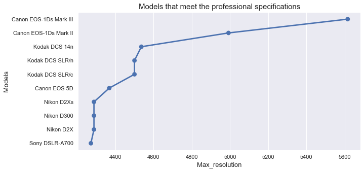

```python
# write the code:

info = pd.DataFrame(df['Max_resolution'].sort_values(ascending = False))
info['Model'] = df['Model']
data = list(map(str,(info['Model'])))
x = list(data[:10])
y = list(info['Max_resolution'][:10])

# plot models that meet the professional specifications
ax = sns.pointplot(x=y,y=x)

#setup the figure size
sns.set(rc={'figure.figsize':(10,5)})
#setup the title and labels of the plot.
ax.set_title("Models that meet the professional specifications",fontsize = 15)
ax.set_xlabel("Max_resolution",fontsize = 13)
ax.set_ylabel("Models",fontsize = 13)
sns.set_style("darkgrid")
```

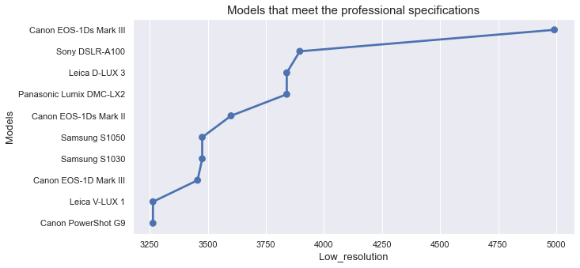

```python
# write the code:

info = pd.DataFrame(df['Low_resolution'].sort_values(ascending = False))
info['Model'] = df['Model']
data = list(map(str,(info['Model'])))
x = list(data[:10])
y = list(info['Low_resolution'][:10])

# plot models that meet the professional specifications
ax = sns.pointplot(x=y,y=x)

#setup the figure size
sns.set(rc={'figure.figsize':(10,5)})
#setup the title and labels of the plot.
ax.set_title("Models that meet the professional specifications",fontsize = 15)
ax.set_xlabel("Low_resolution",fontsize = 13)
ax.set_ylabel("Models",fontsize = 13)
sns.set_style("darkgrid")
```

### Based on the previous three illustrations, most models that meet the professional specifications are:

#### 1- Canon EOS-1Ds Mark III - it is the most compatible.

#### 2- Canon EOS-1Ds Mark II.

#### 3- Kodak DCS 14n.

#### 3- How has specifications evolved over the years?

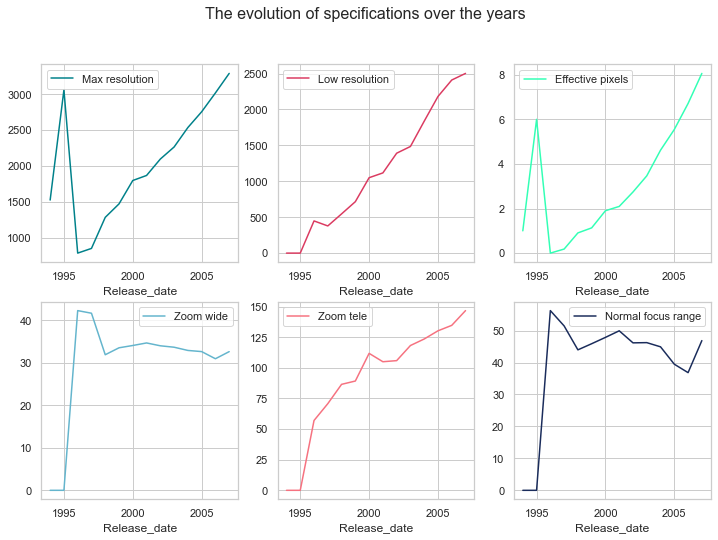

```python
# write the code:
sns.set_style("whitegrid")
#make a subplot of size 3,3.
fig, ax = plt.subplots(2,3,figsize = (12,8))

#set the title of the subplot.
fig.suptitle('The evolution of specifications over the years',fontsize = 16)

#plot
df.groupby('Release_date').mean()['Max_resolution'].plot(label='Max resolution' ,color='#00818a',ax = ax[0][0],legend=True)
df.groupby('Release_date').mean()['Low_resolution'].plot(label = "Low resolution",color='#db3b61',ax = ax[0][1],legend=True)
df.groupby('Release_date').mean()['Effective_pixels'].plot(label = "Effective pixels",color='#33FFB5',ax = ax[0][2],legend=True)
df.groupby('Release_date').mean()['Zoom_wide'].plot(label = "Zoom wide",color='c',ax = ax[1][0],legend=True)
df.groupby('Release_date').mean()['Zoom_tele'].plot(label = "Zoom tele",color='#f67280',ax = ax[1][1],legend=True)
df.groupby('Release_date').mean()['Normal_focus_range'].plot(label = "Normal focus range",color='#1a2c5b',ax = ax[1][2],legend=True)
```

#### Max resolution: this property developed tremendously in 1995 and then fell back sharply after that, but since 1997 it has returned gradually and progressively.

#### Low resolution: evolution was growing in them almost exponentially.

#### Effective pixels: As happened with Max resolution, this property evolved tremendously in 1995 and then decreased, but it gradually developed again.

#### Zoom wide (W): In 1996 it also developed terribly, but after that it decreased slightly and continues to fluctuate at an almost constant rate between high and low, evolving over the years, and perhaps this is because this property is not widely used.

#### Zoom tele (T): The evolution in it was growing in an almost ascending order.

#### Normal focus range: As is the case with Zoom wide, it was highest in 1996 and then fell back slightly and then oscillated relatively steadily.

## Conclusion

### This data was collected by Some camera enthusiast and described 1,000 cameras based on 13 properties.

### In this project, we explained some of the camera-related specifications, sorted the most popular companies in the dataset, and classified the models in terms of prices, professional specifications, weight relationship to those specifications, and lastly how these specifications have evolved over the years.

```python
from IPython.display import HTML

HTML('''<script>
code_show=true;
function code_toggle() {
 if (code_show){
 $('div.input').hide();
 } else {
 $('div.input').show();
 }
 code_show = !code_show
}
$( document ).ready(code_toggle);
</script>
<form action="javascript:code_toggle()"><input type="submit" value="Click here to toggle on/off the raw code."></form>''')
```

```python
! jupyter nbconvert slide_project_part2.ipynb --to slides --post serve --template output_toggle
```

[output not shown]